# lab5-cp1

Lucas Diniz

22/08/2017

# Como conquistar o crush (tutorial)

Todo mundo em algum momento provavelmente já se questionou : Será que eu tenho chance com fulano/fulana? O que eu tenho que fazer pra conquistar essa pessoa? O que será que faz com que ela/ele goste de outra pessoa?

Você provavelmente pensou na resposta óbvia, **beleza**. Mas… será que é só isso mesmo? **NÃO!** Existem outros fatores envolvidos e beleza não é a resposta mágica para um vida amorosa de sucesso. Iremos aqui analisar dados sobre vários encontros no modelo *speed-dating* (pode ir no google rs) entre pessoas desconhecidas. Ao final desses encontros todas as pessoas envolvidas preencheram um formulário detalhando o que acharam da outra pessoa com quem se encontraram. Nós vamos utilizar esses dados para verificar quais são as características cruciais para que uma pessoa goste de outra.

Vamos direto ao ponto, os dados que vamos analisar de cada encontro consistem basicamente em:  
**like**: O quanto a pessoa 1 gostou da pessoa 2.  
**attr**: O quanto a pessoa 1 achou a pessoa 2 atraente.  
**fun**: Quão divertida(o) a pessoa 1 achou a pessoa 2.  
**intel**: Quão inteligente a pessoa 1 achou a pessoa 2.  
**shar**: O quanto a pessoa 1 achou que compartilha interesses com a pessoa 2.

Observemos primeiro a relação entre as variáveis citadas do ponto de vista dos homens, dando foco principalmente nas relações da variável *like* com as outras variáveis:

[output not shown]

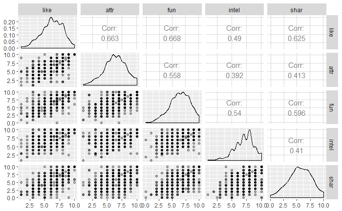

```r
  dados_homens %>%
    select(like, attr, fun, intel, shar) %>%
    ggpairs(size = .5,
            lower = list(continuous = wrap("points", alpha = 0.3)))
```

Podemos notar que para os homens que fizeram o experimento, na hora de decidir se gosta de alguém ou não o bom-humor é o fator **MAIS** importante. Contudo beleza, e compartilhamento de interesses ainda aparecem como quesitos importantes. Aparantemente inteligência não parece ser um fator importante para os homens :p (Não me surpreendi com esse resultado hahaha).

[output not shown]

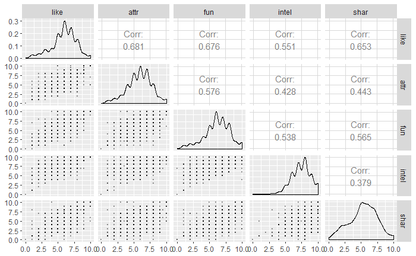

```r
  dados_mulheres %>%
    select(like, attr, fun, intel, shar) %>%
    ggpairs(size = .5,
            lower = list(continuous = wrap("points", size = .5, alpha = 0.3)))
```

Já para as mulheres obtivemos um resultado parecido, contudo, o fator beleza é o mais importante. Seguido de perto por bom-humor e compartilhamento de interesses. As mulheres parecem também se importar mais com o quesito inteligência, porém não tanto quanto eu esperava rs.

| term | estimate | std.error | statistic | p.value |
| --- | --- | --- | --- | --- |
| (Intercept) | 0.4932126 | 0.04355772 | 11.32320 | 9.635463e-28 |
| log(attr) | 0.7155194 | 0.02486343 | 28.77798 | 6.632520e-127 |

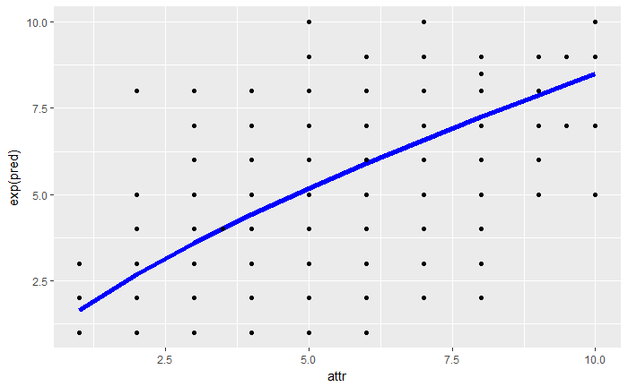

```r
dados_mulheres <- dados_mulheres %>% filter(attr > 0, fun > 0)
mulheres.model = lm(log(like) ~ log(attr), data = dados_mulheres)
tidy(mulheres.model)

mulheresAugmented = dados_mulheres %>%
  add_predictions(mulheres.model) %>%
  add_residuals(mulheres.model)
# Modelo x dados
mulheresAugmented %>%
  ggplot(aes(x = attr)) +
  geom_line(aes(y = exp(pred)), size = 2, colour = "blue") +
  geom_point(aes(y = like))
```

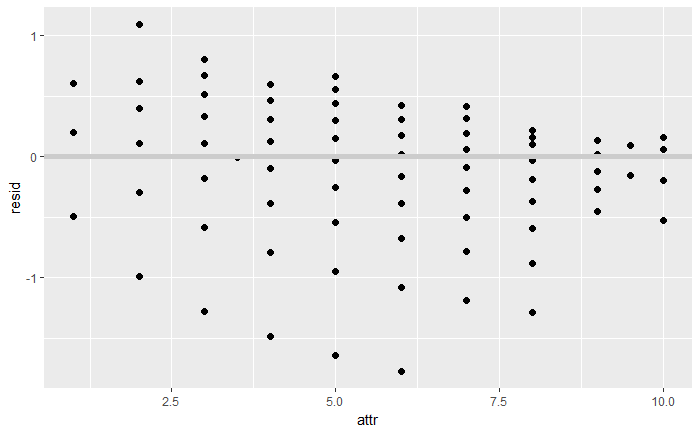

```r
# Resíduos x dados
mulheresAugmented %>%
  ggplot(aes(x = attr)) +
  geom_point(aes(y = resid), size = 2, position = "dodge") +
  geom_ref_line(h = 0, colour = "grey80")
```

```r
tidy(mulheres.model, conf.int = TRUE)
```

| term | estimate | std.error | statistic | p.value | conf.low | conf.high |
| --- | --- | --- | --- | --- | --- | --- |
| (Intercept) | 0.4932126 | 0.04355772 | 11.32320 | 9.635463e-28 | 0.4077165 | 0.5787087 |
| log(attr) | 0.7155194 | 0.02486343 | 28.77798 | 6.632520e-127 | 0.6667169 | 0.7643219 |

```r
glance(mulheres.model, conf.int = TRUE)
```

| r.squared | adj.r.squared | sigma | statistic | p.value | df | logLik | AIC | BIC | deviance | df.residual |
| --- | --- | --- | --- | --- | --- | --- | --- | --- | --- | --- |
| 0.4991479 | 0.4985452 | 0.2927002 | 828.1724 | 6.63252e-127 | 2 | -157.5453 | 321.0907 | 335.2658 | 71.19458 | 831 |